# Sentiment Analysis on Amazon Fine Food Reviews

### Comparing NLTK's VADER and HuggingFace's RoBERTa Transformer Model

## Project Overview

This project explores **sentiment analysis** on a dataset of Amazon Fine Food Reviews. We'll compare two different approaches to determining the sentiment (positive, neutral, or negative) of customer reviews:

1. **VADER (Valence Aware Dictionary and sEntiment Reasoner)** - A rule-based, "bag of words" sentiment model from NLTK.
2. **RoBERTa** - A pretrained transformer model from HuggingFace that accounts for context and word order.

## Goals

- Perform basic exploratory data analysis (EDA) on the review dataset
- Apply NLTK's tokenization, part-of-speech tagging, and named entity recognition
- Generate sentiment scores using VADER
- Generate sentiment scores using a pretrained RoBERTa transformer model
- Visualize and compare the results from both models against the actual star ratings
- Identify interesting mismatches between predicted sentiment and star ratings
- Demonstrate a quick alternative using HuggingFace's `pipeline` API

## Dataset

The dataset used is the [Amazon Fine Food Reviews](https://www.kaggle.com/datasets/snap/amazon-fine-food-reviews) dataset, containing reviews of food products sold on Amazon. For this project, we work with a subset of 500 reviews to keep runtimes manageable.

## Setup

First, we import the necessary libraries and download the required NLTK resources.

```python
import pandas as pd
import numpy as np
import matplotlib.pyplot as plt
import seaborn as sns

plt.style.use('ggplot')

import nltk
nltk.download('punkt')
nltk.download('punkt_tab') # required for Python 3.13 / NLTK 3.9+
nltk.download('averaged_perceptron_tagger_eng') # needed for pos_tag on NLTK 3.9+
nltk.download('maxent_ne_chunker_tab')  # NLTK 3.9+ renamed version
nltk.download('words')
nltk.download('vader_lexicon')
```

```
True
```

## Step 1: Load the Data

We load the Amazon Fine Food Reviews dataset and limit it to the first 500 rows for this analysis.

```python
# Read in data
df = pd.read_csv('/Users/ameerjordan/Desktop/Data/Data Science Portfolio Projects/Python Sentiment Analysis Project with NLTK/Reviews.csv')
print(df.shape)
df = df.head(500)
print(df.shape)
```

```
(568454, 10)
(500, 10)
```

```python
df.head()
```

|  | Id | ProductId | UserId | ProfileName | HelpfulnessNumerator | HelpfulnessDenominator | Score | Time | Summary | Text |
| --- | --- | --- | --- | --- | --- | --- | --- | --- | --- | --- |
| 0 | 1 | B001E4KFG0 | A3SGXH7AUHU8GW | delmartian | 1 | 1 | 5 | 1303862400 | Good Quality Dog Food | I have bought several of the Vitality canned d... |
| 1 | 2 | B00813GRG4 | A1D87F6ZCVE5NK | dll pa | 0 | 0 | 1 | 1346976000 | Not as Advertised | Product arrived labeled as Jumbo Salted Peanut... |
| 2 | 3 | B000LQOCH0 | ABXLMWJIXXAIN | Natalia Corres "Natalia Corres" | 1 | 1 | 4 | 1219017600 | "Delight" says it all | This is a confection that has been around a fe... |
| 3 | 4 | B000UA0QIQ | A395BORC6FGVXV | Karl | 3 | 3 | 2 | 1307923200 | Cough Medicine | If you are looking for the secret ingredient i... |
| 4 | 5 | B006K2ZZ7K | A1UQRSCLF8GW1T | Michael D. Bigham "M. Wassir" | 0 | 0 | 5 | 1350777600 | Great taffy | Great taffy at a great price. There was a wid... |

## **Quick EDA**

Let's take a quick look at the distribution of star ratings in our dataset. This gives us a sense of the class balance before diving into sentiment scoring.

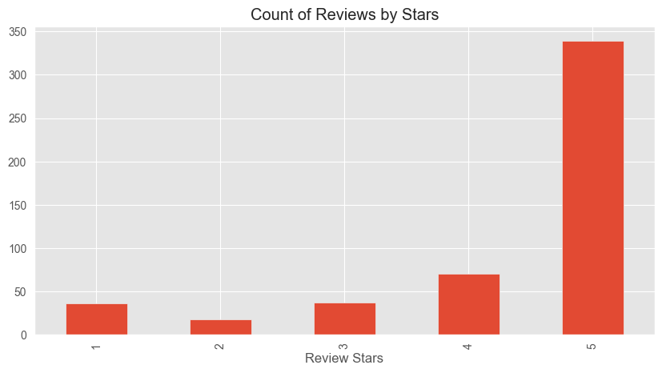

```python
ax = df['Score'].value_counts().sort_index() \
    .plot(kind='bar' ,
          title='Count of Reviews by Stars' ,
            figsize=(10, 5))
ax.set_xlabel('Review Stars')
plt.show()
```

Notice that the dataset is heavily skewed toward 5-star reviews, which is common for product review datasets. Keep this imbalance in mind when interpreting later results.

# **Basic NLTK**

Before applying sentiment analysis, let's explore some of NLTK's core NLP tools using a single example review:

- **Tokenization**: splitting text into individual words/tokens
- **Part-of-Speech (POS) tagging**: labeling each token with its grammatical role
- **Named Entity Recognition (NER)**: identifying entities like people, organizations, and locations

```python
example = df['Text'][50]
print(example)
```

```
This oatmeal is not good. Its mushy, soft, I don't like it. Quaker Oats is the way to go.
```

**Tokenize the example text:**

```python
tokens = nltk.word_tokenize(example)
tokens[:10]
```

```
['This', 'oatmeal', 'is', 'not', 'good', '.', 'Its', 'mushy', ',', 'soft']
```

**Tag each token with its part of speech:**

```python
tagged = nltk.pos_tag(tokens)
tagged[:10]
```

```
[('This', 'DT'),
 ('oatmeal', 'NN'),
 ('is', 'VBZ'),
 ('not', 'RB'),
 ('good', 'JJ'),
 ('.', '.'),
 ('Its', 'PRP$'),
 ('mushy', 'NN'),
 (',', ','),
 ('soft', 'JJ')]
```

**Group tagged tokens into chunks to identify named entities:**

```python
entities = nltk.chunk.ne_chunk(tagged)
entities.pprint()
```

```
(S
  This/DT
  oatmeal/NN
  is/VBZ
  not/RB
  good/JJ
  ./.
  Its/PRP$
  mushy/NN
  ,/,
  soft/JJ
  ,/,
  I/PRP
  do/VBP
  n't/RB
  like/VB
  it/PRP
  ./.
  (ORGANIZATION Quaker/NNP Oats/NNPS)
  is/VBZ
  the/DT
  way/NN
  to/TO
  go/VB
  ./.)
```

# **Step 2. VADER Sentiment Scoring**

### We will use NLTK's SentimentIntensityAnalyzer to get the neg/neu/pos scores of the text

```
This uses a "bag of words" approach:
    1. Stop words are removed
    2. Each word is scored and combined to a total score
```

```python
from nltk.sentiment import SentimentIntensityAnalyzer
from tqdm.auto import tqdm

sia = SentimentIntensityAnalyzer()
```

Let's test VADER on a couple of simple example sentences before applying it to the dataset.

```python
sia.polarity_scores('I am so happy!')
```

```
{'neg': 0.0, 'neu': 0.318, 'pos': 0.682, 'compound': 0.6468}
```

```python
sia.polarity_scores('This is the worst thing ever.')
```

```
{'neg': 0.451, 'neu': 0.549, 'pos': 0.0, 'compound': -0.6249}
```

Now let's run VADER on our example review from earlier:

```python
sia.polarity_scores(example)
```

```
{'neg': 0.22, 'neu': 0.78, 'pos': 0.0, 'compound': -0.5448}
```

## Step 3: Run VADER on the Entire Dataset

Now that we understand how VADER works, let's apply `polarity_scores` to every review in the dataset and store the results.

```python
# Run the polarity score on the entire dataset
res = {}
for i, row in tqdm(df.iterrows(), total=len(df)):
    text = row['Text']
    myid = row['Id']
    res[myid] = sia.polarity_scores(text)
```

Combine the VADER results with the original dataframe so we can compare sentiment scores against the actual star ratings (`Score`).

```python
vaders = pd.DataFrame(res).T
vaders = vaders.reset_index()
vaders = vaders.rename(columns={'index': 'Id'})
vaders = vaders.merge(df, on='Id', how='left')
```

```python
# Now we have sentiment score and metadata
vaders.head()
```

|  | Id | neg | neu | pos | compound | ProductId | UserId | ProfileName | HelpfulnessNumerator | HelpfulnessDenominator | Score | Time | Summary | Text |
| --- | --- | --- | --- | --- | --- | --- | --- | --- | --- | --- | --- | --- | --- | --- |
| 0 | 1 | 0.000 | 0.695 | 0.305 | 0.9441 | B001E4KFG0 | A3SGXH7AUHU8GW | delmartian | 1 | 1 | 5 | 1303862400 | Good Quality Dog Food | I have bought several of the Vitality canned d... |
| 1 | 2 | 0.138 | 0.862 | 0.000 | -0.5664 | B00813GRG4 | A1D87F6ZCVE5NK | dll pa | 0 | 0 | 1 | 1346976000 | Not as Advertised | Product arrived labeled as Jumbo Salted Peanut... |
| 2 | 3 | 0.091 | 0.754 | 0.155 | 0.8265 | B000LQOCH0 | ABXLMWJIXXAIN | Natalia Corres "Natalia Corres" | 1 | 1 | 4 | 1219017600 | "Delight" says it all | This is a confection that has been around a fe... |
| 3 | 4 | 0.000 | 1.000 | 0.000 | 0.0000 | B000UA0QIQ | A395BORC6FGVXV | Karl | 3 | 3 | 2 | 1307923200 | Cough Medicine | If you are looking for the secret ingredient i... |
| 4 | 5 | 0.000 | 0.552 | 0.448 | 0.9468 | B006K2ZZ7K | A1UQRSCLF8GW1T | Michael D. Bigham "M. Wassir" | 0 | 0 | 5 | 1350777600 | Great taffy | Great taffy at a great price. There was a wid... |

## Plot VADER results

We'd expect the **compound score** (an overall measure of sentiment from -1 to +1) to increase with the number of stars given. Let's visualize this relationship.

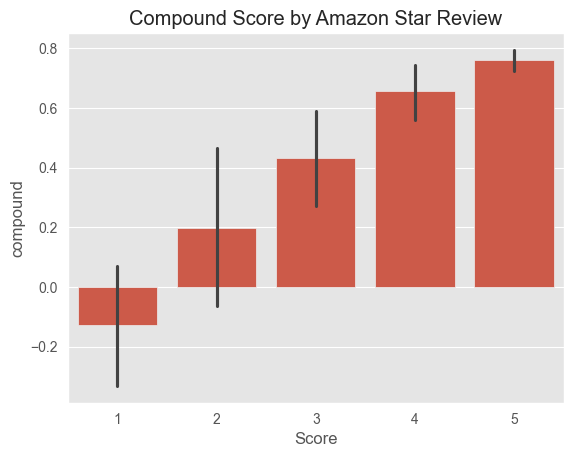

```python
ax = sns.barplot(data=vaders, x='Score', y='compound')
ax.set_title('Compound Score by Amazon Star Review')
plt.show()
```

Now let's break this down further by looking at the **positive**, **neutral**, and **negative** sentiment scores separately across star ratings.

```
<function matplotlib.pyplot.show(close=None, block=None)>
```

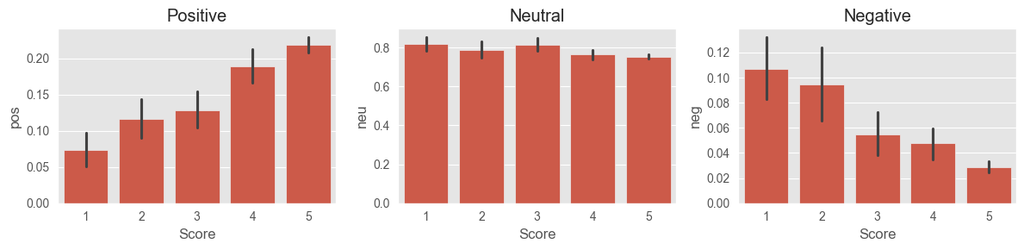

```python
fig, axs = plt.subplots(1, 3, figsize=(12, 3))
sns.barplot(data=vaders, x='Score', y='pos', ax=axs[0])
sns.barplot(data=vaders, x='Score', y='neu', ax=axs[1])
sns.barplot(data=vaders, x='Score', y='neg', ax=axs[2])
axs[0].set_title('Positive')
axs[1].set_title('Neutral')
axs[2].set_title('Negative')
plt.tight_layout()
plt.show
```

The results align with intuition: positive scores rise with star rating, while negative scores fall. This confirms VADER captures a meaningful sentiment signal, though it's a simple bag-of-words approach with no understanding of context, sarcasm, or word order.

# **Step 4. Roberta Pretrained Model**

```
    - Use a model trained of a large corpus of data
    - Transformer model accounts for the words but also the context related to other words
```

```python
from transformers import AutoTokenizer
from transformers import AutoModelForSequenceClassification
from scipy.special import softmax
```

We'll use the `cardiffnlp/twitter-roberta-base-sentiment` model, a RoBERTa model fine-tuned for sentiment classification on tweets. It outputs three scores: negative, neutral, and positive.

```python
MODEL = f"cardiffnlp/twitter-roberta-base-sentiment"
tokenizer = AutoTokenizer.from_pretrained(MODEL)
model = AutoModelForSequenceClassification.from_pretrained(MODEL)
```

For comparison, let's first revisit VADER's score on our example review:

```python
# VADER results on example
print(example)
sia.polarity_scores(example)
```

```
This oatmeal is not good. Its mushy, soft, I don't like it. Quaker Oats is the way to go.
```

```
{'neg': 0.22, 'neu': 0.78, 'pos': 0.0, 'compound': -0.5448}
```

Now let's run the same example through the RoBERTa model:

```python
# Run for Roberta Model
encoded_text = tokenizer(example, return_tensors='pt')
output = model(**encoded_text)
scores = output[0][0].detach().numpy()
scores = softmax(scores)
scores_dict = {
    'roberta_neg' : float(scores[0]),
    'roberta_neu': float(scores[1]),
    'roberta_pos': float(scores[2]),
}
print(scores_dict)
```

```
{'roberta_neg': 0.9763551354408264, 'roberta_neu': 0.02068747580051422, 'roberta_pos': 0.0029573736246675253}
```

Let's wrap this logic into a reusable function so we can easily apply it to every review.

```python
def polarity_scores_roberta(example):
    encoded_text = tokenizer(example, return_tensors='pt')
    output = model(**encoded_text)
    scores = output[0][0].detach().numpy()
    scores = softmax(scores)
    scores_dict = {
        'roberta_neg' : float(scores[0]),
        'roberta_neu': float(scores[1]),
        'roberta_pos': float(scores[2]),
    }
    return scores_dict
```

## Run Both Models on the Full Dataset

Now we loop through all 500 reviews and compute both VADER and RoBERTa sentiment scores for each. Some reviews may be too long for the RoBERTa tokenizer, so we wrap the call in a `try/except` block to skip any that cause errors.

```python
res = {}
for i, row in tqdm(df.iterrows(), total=len(df)):
    try:
        text = row['Text']
        myid = row['Id']
        vader_result = sia.polarity_scores(text)
        vader_result_rename = {}
        for key, value in vader_result.items():
            vader_result_rename[f"vader_{key}"] = value
        roberta_result = polarity_scores_roberta(text)
        both = {**vader_result_rename, **roberta_result}
        res[myid] = both
    except RuntimeError:
        print(f'Broke for id {myid}')
```

```
Broke for id 83
```

```
Broke for id 187
```

Merge the combined results back with the original dataframe.

```python
results_df = pd.DataFrame(res).T
results_df = results_df.reset_index()
results_df = results_df.rename(columns={'index': 'Id'})
results_df = results_df.merge(df, on='Id', how='left')
```

```python
results_df.head()
```

|  | Id | vader_neg | vader_neu | vader_pos | vader_compound | roberta_neg | roberta_neu | roberta_pos | ProductId | UserId | ProfileName | HelpfulnessNumerator | HelpfulnessDenominator | Score | Time | Summary | Text |
| --- | --- | --- | --- | --- | --- | --- | --- | --- | --- | --- | --- | --- | --- | --- | --- | --- | --- |
| 0 | 1 | 0.000 | 0.695 | 0.305 | 0.9441 | 0.009624 | 0.049980 | 0.940395 | B001E4KFG0 | A3SGXH7AUHU8GW | delmartian | 1 | 1 | 5 | 1303862400 | Good Quality Dog Food | I have bought several of the Vitality canned d... |
| 1 | 2 | 0.138 | 0.862 | 0.000 | -0.5664 | 0.508986 | 0.452414 | 0.038600 | B00813GRG4 | A1D87F6ZCVE5NK | dll pa | 0 | 0 | 1 | 1346976000 | Not as Advertised | Product arrived labeled as Jumbo Salted Peanut... |
| 2 | 3 | 0.091 | 0.754 | 0.155 | 0.8265 | 0.003229 | 0.098068 | 0.898704 | B000LQOCH0 | ABXLMWJIXXAIN | Natalia Corres "Natalia Corres" | 1 | 1 | 4 | 1219017600 | "Delight" says it all | This is a confection that has been around a fe... |
| 3 | 4 | 0.000 | 1.000 | 0.000 | 0.0000 | 0.002295 | 0.090219 | 0.907486 | B000UA0QIQ | A395BORC6FGVXV | Karl | 3 | 3 | 2 | 1307923200 | Cough Medicine | If you are looking for the secret ingredient i... |
| 4 | 5 | 0.000 | 0.552 | 0.448 | 0.9468 | 0.001635 | 0.010302 | 0.988063 | B006K2ZZ7K | A1UQRSCLF8GW1T | Michael D. Bigham "M. Wassir" | 0 | 0 | 5 | 1350777600 | Great taffy | Great taffy at a great price. There was a wid... |

## Compare Scores between models

# Step 5. Combine and compare

A pairplot lets us visualize the relationships between all VADER and RoBERTa score columns at once, colored by the actual star rating (`Score`). This helps us see how well each model's scores separate the different rating classes, and whether the two models agree with each other.

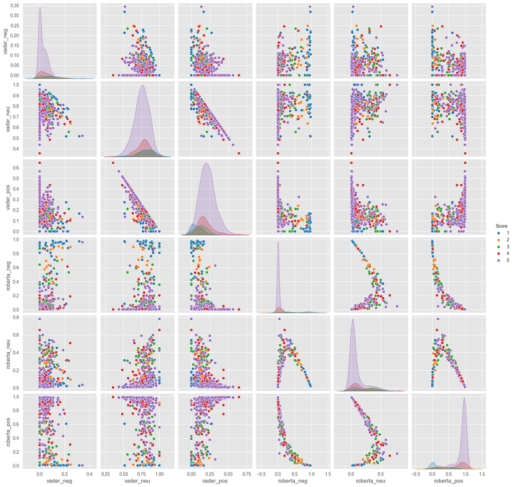

```python
sns.pairplot(data=results_df,
             vars=['vader_neg', 'vader_neu', 'vader_pos',
                 'roberta_neg', 'roberta_neu', 'roberta_pos'],
             hue='Score',
             palette='tab10')
plt.show()
```

From the pairplot, we can generally see that RoBERTa's scores tend to form tighter, more separated clusters by star rating compared to VADER, suggesting it may capture sentiment more accurately due to its contextual understanding.

# **Step 6: Review Examples**

```
- Positive 1-Star and Negative 5-Star Reviews
```

Lets look at some exmaples where the model scoring and review score differ the most

**Case 1: Reviews with a 1-star rating, but high RoBERTa positive score**

```python
results_df.query('Score == 1') \
    .sort_values('roberta_pos', ascending=False)['Text'].values[0]
```

```
'I felt energized within five minutes, but it lasted for about 45 minutes. I paid $3.99 for this drink. I could have just drunk a cup of coffee and saved my money.'
```

**Case 2: Reviews with a 1-star rating, but high VADER positive score**

```python
results_df.query('Score == 1') \
    .sort_values('vader_pos', ascending=False)['Text'].values[0]
```

```
'So we cancelled the order.  It was cancelled without any problem.  That is a positive note...'
```

Both models picked up on positive language despite the reviewer giving only 1 star — likely because the review text describes something positive (e.g., the product itself) while the negative rating reflects a different issue (e.g., shipping, packaging, or price).

### Now let's look at the opposite case: 5-star reviews that score as negative

```python
# negative sentiment 5-Star review
```

**Case 3: Reviews with a 5-star rating, but high RoBERTa negative score**

```python
results_df.query('Score == 5') \
    .sort_values('roberta_neg', ascending=False)['Text'].values[0]
```

```
'this was sooooo deliscious but too bad i ate em too fast and gained 2 pds! my fault'
```

**Case 4: Reviews with a 5-star rating, but high VADER negative score**

```python
results_df.query('Score == 5') \
    .sort_values('vader_neg', ascending=False)['Text'].values[0]
```

```
'this was sooooo deliscious but too bad i ate em too fast and gained 2 pds! my fault'
```

These mismatches highlight a key limitation of sentiment scoring: the **text content** of a review doesn't always perfectly align with the **numeric star rating** the reviewer chose. Sentiment models can surface these interesting edge cases for further investigation.

# Extra: The Transformers Pipeline

```
- Quixk & easy way to run sentiment predictions
```

HuggingFace's `pipeline` API abstracts away the tokenization, model loading, and post-processing steps we did manually above. It's a great way to quickly get sentiment predictions with just a couple lines of code.

```python
from transformers import pipeline

sent_pipeline = pipeline("sentiment-analysis")
```

```
[transformers] No model was supplied, defaulted to distilbert/distilbert-base-uncased-finetuned-sst-2-english and revision 714eb0f.
Using a pipeline without specifying a model name and revision in production is not recommended.
```

Let's test it on a simple example:

```python
sent_pipeline('I love sentiment analysis!')
```

```
[{'label': 'POSITIVE', 'score': 0.9997853636741638}]
```

## Conclusion

In this project, we explored two different approaches to sentiment analysis on Amazon Fine Food Reviews:

- **VADER** offers a fast, lightweight, rule-based approach that works reasonably well for general sentiment trends, but struggles with nuance, context, and sarcasm.
- **RoBERTa** (a transformer-based model) leverages contextual understanding from large-scale pretraining, generally producing sharper and more accurate sentiment distinctions.

We also saw that star ratings don't always match the sentiment expressed in the review text itself, which is an important consideration when using star ratings as a proxy for sentiment labels.